# Evo_Analysis

## What is Evolutionary Medicine?

A central question in evolutionary medicine is “why are disease risk genetic variants still around?”

This paper on the evolution of cancer is a great read for those new to the topic: https://onlinelibrary.wiley.com/doi/full/10.1111/eva.12034

My favorite line from the paper is “*It is disturbing to recognize that natural selection does not shape organisms directly for health or longevity.*”

1. Mismatch with the modern environment
2. Co-evolution with pathogens
3. Constraints on selection
4. Trade-offs
5. Reproduction at the cost of health
6. Evolved capacities for defense and their costs

For a deeper look at the evolution of disease traits see our review: https://www.nature.com/articles/s41576-020-00305-9

## Evolution in the genome

One way we can try to understand the evolutionary processes that have shaped traits is to look for imprints in the genome left behind by selection.

Our group has developed a pipeline that will characterize enrichment or depletion of metrics that have been computed to identify regions of the genome that have been impacted by

- Negative Selection (Substitution rate, sequence conservation)
- Positive Selection (Substitution rate, sequence conservation, haplotype structure)
- Balancing Selection (Balanced polymorphisms)
- Local Adaptation (Population differentiation)

This analysis will identify regions of the genome (composed of 1 to may SNPs) that have signatures consistent with these evolutionary forces.

While this analysis is helpful, we may want to know more about these regions. We can then build a theory (or evolutionary story) about *why* this signature exists in this region.

This is not an exhaustive list of potential questions to answer! This will hopefully lead you to more analyses.

## Evolutionary Checklist

First I’ll give an overview of the questions I go through when investigating the evolutionary history of a region (or even a gene). Then I will go into detail about what resources I use to answer these questions.

1. If we are analyzing a region identified in a GWAS, which alleles (or haplotype) are the **risk** alleles?
2. What is known about the **consequence** of the variation in the region of interest?
3. Are the variants associated with any changes in **gene expression**?
4. Are the variants associated with any other traits or disorders?
5. How deeply is the region conserved or not conserved?
6. Do human populations vary in this region?
7. Do associated genes have any known functions?

## Example Region

To illustrate these analyses I will provide an example analysis. I recently conducted an evolutionary analysis for a GWAS conducted on preterm birth and gestational age. (https://www.nature.com/articles/s41588-023-01343-9)

One of the leading SNPs is rs7650602

**NOTE on RS numbers**: each variant in the human genome is assigned an “rs” number. This number will reference the same position in the human genome regardless of the version of the genome. Be sure to double and triple check which version of the genome you are using if you are identifying a SNP by the chromosome and position.

### 1. Risk allele

There is no standardized way to report which SNP allele increases or decreases disease risk. You will likely need to go into the reporting to identify the risk allele.

*Example:* The GWAS used in this analysis reported the summary statistics as below:

| CHR | POS | EFF | REF | RSID | SAMPLESIZE | EAF | BETA | SE | pvalue |
| --- | --- | --- | --- | --- | --- | --- | --- | --- | --- |
| **3** | **1.41E+08** | **T** | **C** | **rs7650602** | **192643** | **0.5233** | **-0.3122** | **0.0447** | **3.01E-12** |
| 3 | 1.41E+08 | T | G | rs145418929 | 171646 | 0.9736 | -0.2752 | 0.2375 | 0.2467 |
| 3 | 1.41E+08 | C | A | rs115605995 | 172653 | 0.9614 | 0.142 | 0.1156 | 0.2192 |

From this you can see they report an effect (EFF) and reference (REF) allele. To understand the effect the alleles have on the trait (risk of preterm birth/PTB) we need to look at the beta value

The beta value reports the per unit increase or decrease in the outcome. So for our SNP the beta value is -0.3122. Therefore there is a **decrease** in the *days of gestation* for the effect allele (T)

Effect Allele = T = decrease days= risk allele

Reference Allele = C = increased days = protective allele

## 2. Known variant consequences?

Many SNPs in the human genome have confirmed or hypothesized functions. There are several resources we can turn to to find these confirmed or known consequences.

**NIH dbSNP** https://www.ncbi.nlm.nih.gov/snp/

[figure not shown]

In dbSNP we can see that this variant rs7650602 is in the **intron of the gene ZBTB38**

**Ensembl** snp data ( https://useast.ensembl.org/index.html )

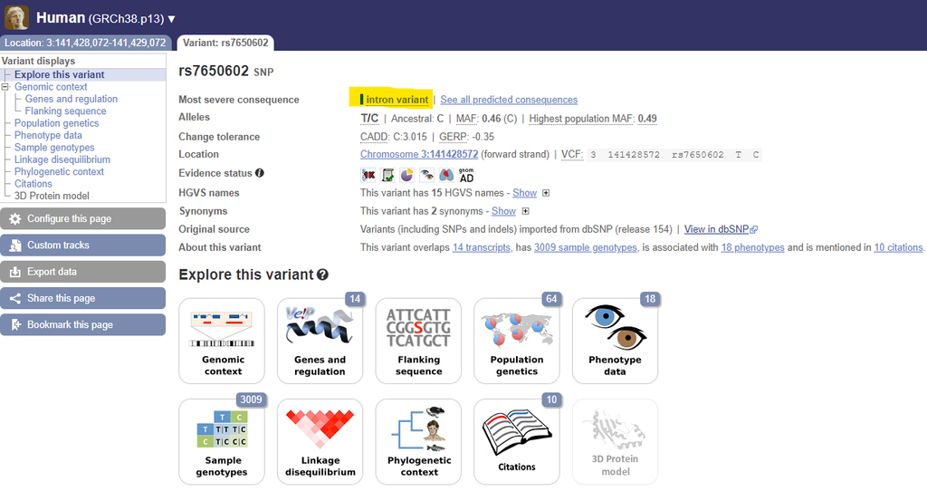

The Ensembl data agrees with the data in the dbSNP. You can also see there is a link to “See all predicted consequences”. This link will take you to see all the predicted consequences if there is more than one.

## 3. Expression Consequences

Many common variants in the human genome have a regulatory function. If we were to find variants that result in non-synonymous changes (aka change amino acid sequences) we would turn to predictions of protein structure. These variants, however, often have severe consequences and are more likely to result in Mendelian disorders.

Determining the regulatory function of a region in the human genome is challenging! But there are several databases that can help us understand which genes may be affected by variation at our SNP.

## **RegulomeDB** (https://regulomedb.org/ )

RegulomeDB has *a lot* of information. You can find information about the various sections here (https://regulomedb.org/regulome-help/#FAQ)

Let’s walk through it.

[figure not shown]

First you will see the coordinates of the genome (in HG38 if you used the default). In this section the most important thing to look at is the **rank**

The ranks range from 1 (most evidence) to 7 (least evidence) for data indicating that this variant is found in a regulatory region.

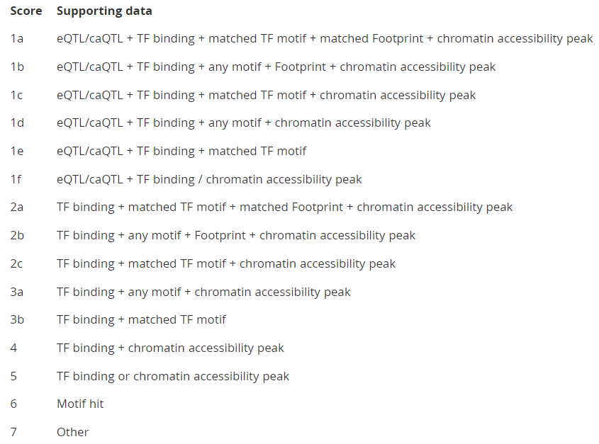

Our SNP has a score of 1f which indicates that there is an eQTL (more to come on this) and either TF binding or a chromatin accessibility peak there.

So, **we have good evidence that our SNP is in a regulatory region**

### ChIP data

ChIP stands for Chromatin immunoprecipitation

You can learn more here: https://www.youtube.com/watch?v=7_-Or4ARyH0 and https://en.wikipedia.org/wiki/Chromatin_immunoprecipitation

The premise of ChIP is that you are able to **sequence the DNA bound to specific proteins**. You tightly bind (cross-link) DNA to Proteins and then selectively isolate the proteins (immunoprecipitation). Then sequence *only* the DNA bound to your protein. You can then generate a map of *where* your protein was bound to the genome.

Our SNP has no ChIP data but I will use a **different SNP** to demonstrate what the results would look like.

Results for SNP rs1316379

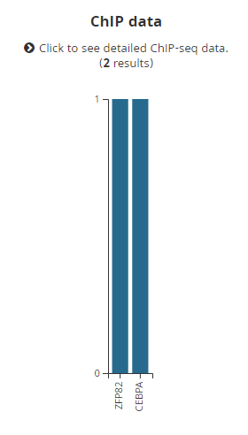

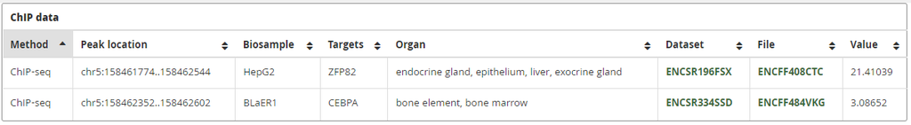

From this data we can see that two proteins ZFP82 and CEBPA are bound to our region of interest and in which organ this was detected. There is very good evidence that these two proteins can bind to our region.

### Chromatin State

DNA is not floating around our cells as double-stranded DNA. Instead DNA is highly organized into three-dimensional structures. The basic structure of DNA is the nucleosome where DNA wraps around histones (euchromatin). These histones then wrap into a fiber (heterochromatin).

When DNA is wrapped up into chromatin, it cannot be expressed. (see more here: https://www.khanacademy.org/science/ap-biology/gene-expression-and-regulation/regulation-of-gene-expression-and-cell-specialization/v/dna-and-chromatin-regulation )

By looking to see if our DNA if interest is exposed (not wrapped up in chromatin) we can ask if this region is transcriptionally active in particular tissues.

The chromatin state provided in regulomeDB is often the result of an analysis conducted in chromHMM ( https://www.ncbi.nlm.nih.gov/pmc/articles/PMC3577932/ )

The various chromatin states predicted are summarized below

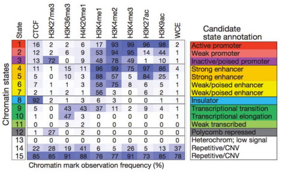

For our region the chromatin state has been found to be associated most frequently with weak transcription or active enhancer activity.

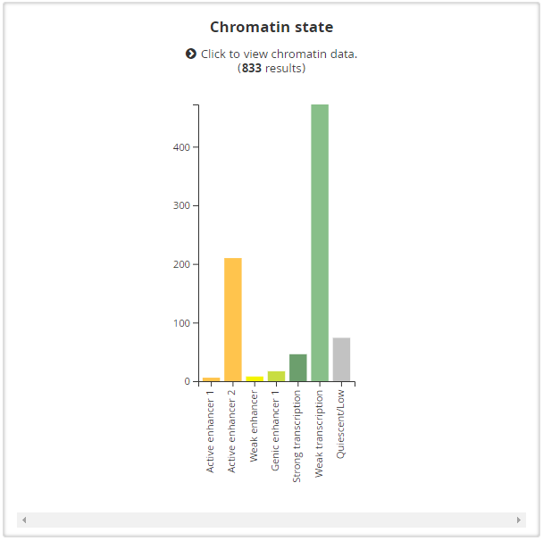

If you click on the chromatin state you can see a more detailed view showing which sample and organ each chromatin state was shown

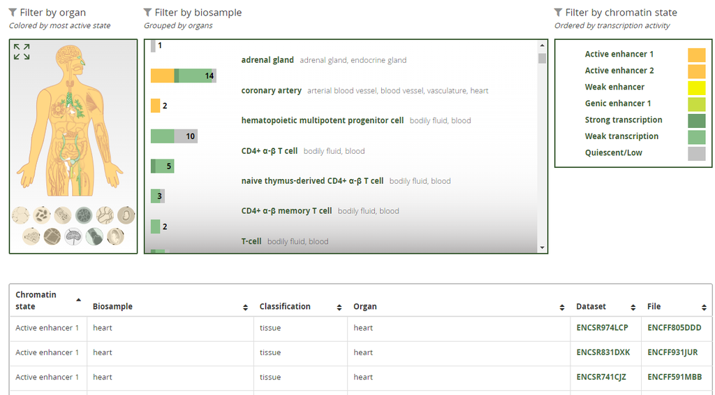

From this, we can see that this region is likely an active enhancer in the heart and coronary artery.

### Accessibility

This section displays results from chromatin accessibility experiments. Accessible chromatin is not condensed and is therefore inferred to be transcriptionally active.

DNase-seq sequences regions of the genome that are sensitive to cleavage by DNase enzyme–aka they are exposed ( https://en.wikipedia.org/wiki/DNase_I_hypersensitive_site )

ATAC-seq stands for **A**ssay for **T**ransposase-**A**ccessible **C**hromatin with high-throughput **seq**uencing. It also attempts to sequence transcriptionally active regions of the genome. ( https://www.activemotif.com/blog-atac-seq )

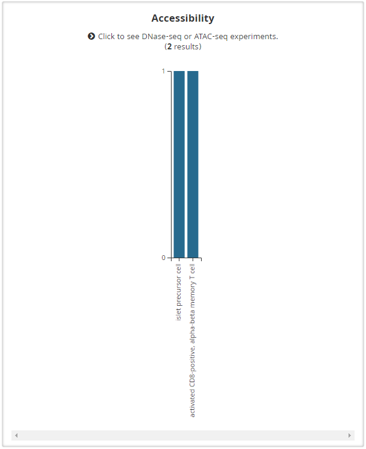

You can see from the summary figure our region was found to be accessible in two tissue samples through DNase-seq experiments.

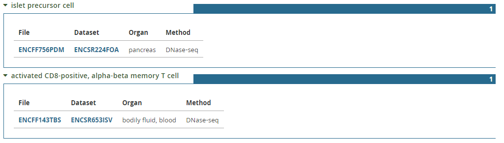

### Motifs

Transcription factors bind to specific genomic sequences known as motifs. Each position in the motif may have a different allowance for different bases. These are often determined using a consensus of known binding motifs. (more: https://www.ebi.ac.uk/training/online/courses/human-genetic-variation-introduction/what-is-genetic-variation/variants-in-transcription-factor-binging-motifs/ )

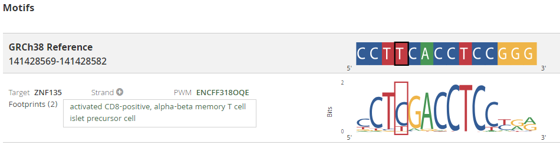

You can see that in a cell line they detected binding of ZNF135. Our SNP has the red box around it. If we recall our protective and risk allele (C = decrease risk; T = increased risk) it looks like the risk allele T may interfere with the binding of ZNF135. The consensus sequence suggests that most of the time there is a C in that position in the motif. We would need to do additional analyses to confirm if C or T has better/worse binding of the TF to the DNA.

### QTL data

QTL stands for Quantitative Trait Locus and is a region or SNP associated with a specific variable trait in the population. An eQTL is an expression-QTL that associates variation in the genome with variance in gene expression. The portal also reports caQTLs which are chromatin accessibility QTLs (read more https://www.illumina.com/techniques/popular-applications/qtl-analysis.html )

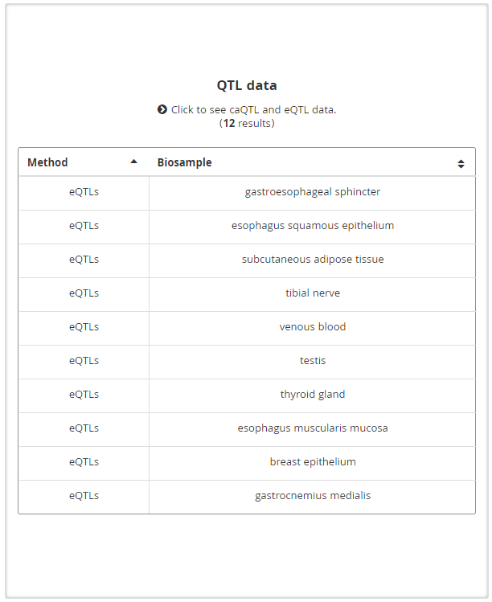

From the snapshot we can see that there are 12 results in this category. We are going to further explore eQTLs below. This data shows that variation at our SNP results in the differential expression of the gene ZBTB38 in multiple tissues

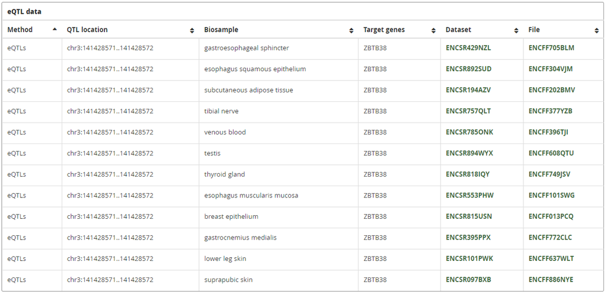

### Genome Browser

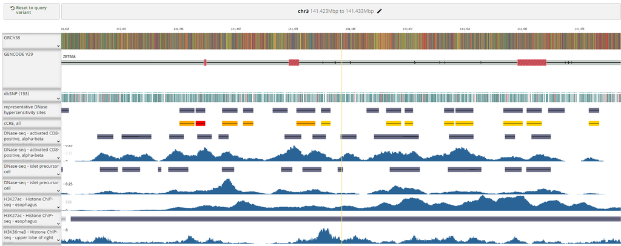

The genome browser gives us an overview of the location of our SNP (yellow line). There are over 422 tracks (data sets) that you can view on the genome browser.

### RegulomeDB summary

Our variant is most likely found in a regulatory region that regulates expression of ZBTB38. This may be through binding of the transcription factor ZNF135

## GTEx database (https://gtexportal.org/home/)

Developmental Genotype-Tissue Expression (dGTEx) Project is an effort to study development-specific genetic effects on gene expression. You can search for the exact SNP of interest.

Searching for **rs7650602** will bring up a Variant Page. This will have information about the variant and it’s position.

[figure not shown]

**eQTL violin plot** will show us how expression changes for the associated gene.

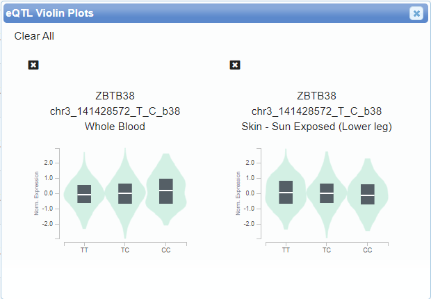

**GTEx IGV Browswer** This will show you a visual of the eQTLs along the genome. You can add and remove tracks.

**Multi-tissue eQTL Plot** This will show a visual of *all* the tissues that this variant is associated with.

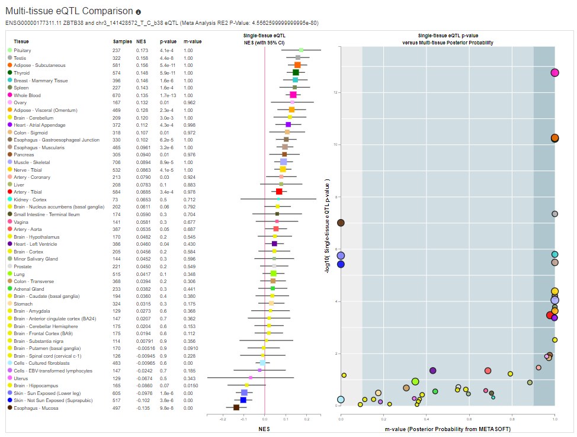

m-value <0.1: Tissue is predicted to NOT have an eQTL effect

m-value >0.9: Tissue is predicted to HAVE an eQTL effect

0.1 <= v-value <= 0.9: Prediction effect is ambiguous

This is why the dots all the way to the left (lowest m-value) are not reported on th previous page. The effect is not robust to additional meta-analysis.

## 4. Pleiotropic effects

### GWAS Catalog

A single gene or locus can affect many different traits. We saw in our GWAS that this SNP can affect gestational age and preterm birth.

This region may be pleiotropic, meaning that variation at this one locus influences multiple traits. We can turn to the GWAS catalog to look for other GWAS that have identified this variant. You can search the variant by it’s rs **rs7650602** number on https://www.ebi.ac.uk/gwas/

The GWAS catalog identified 18 traits with an association with our SNP

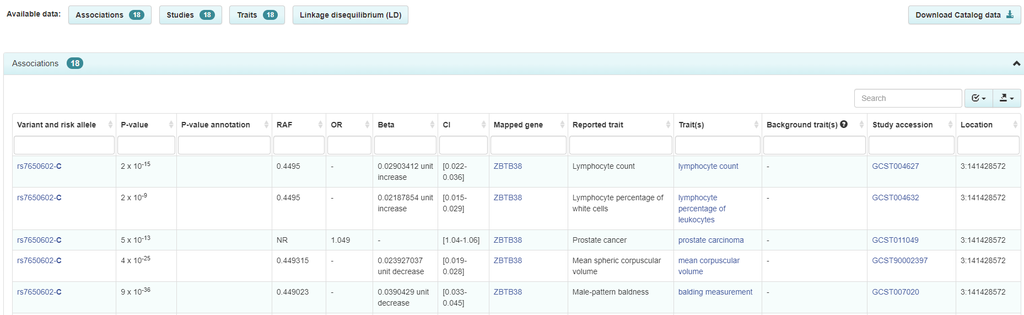

14 traits show increased risk with the C allele. These traits are broadly lymphocyte phenotypes, prostate cancer, male-pattern baldness, red blood cell count, pulmonary disease, and myopia.

3 traits show increased risk with the T allele. *However,* these three are all associated with educational attainment. This is not very helpful to our analysis as there has likely not been significant selection on educational attainment.

Interestingly, our risk allele T is the protective allele for many of these traits! This suggests that there may be trade-offs between these traits.

### PheWAS

A Phenome-wide association study (PheWAS) is essentially the opposite of a GWAS. Where researchers associated a single genomic loci with multiple phenotypes. (more: https://en.wikipedia.org/wiki/Phenome-wide_association_study )

This will help us associate our exact locus with other phenotypes. There are a couple of resources we can use to look at this

GWAS Atlas https://atlas.ctglab.nl/PheWAS

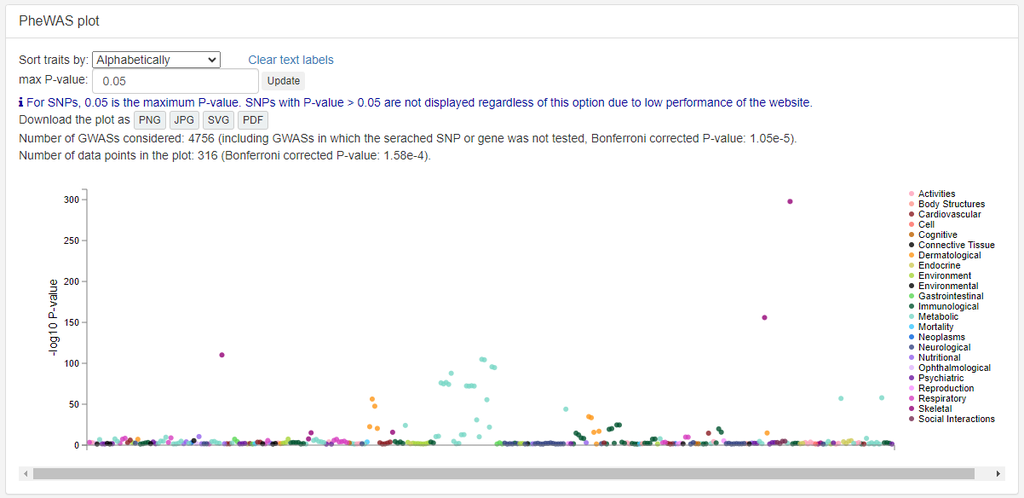

You can see that there are a lot of metabolic traits associated with variation at this position. The two highest points on the right (purple) are both associated with height. From the PheWAS table you can see that the effect allele (EA) is C in many of the traits associated with height and size. This suggests that the protective allele C (for our trait PTB) is associated with increased height and mass.

*Side note: This may not seem intuitive. This suggests that people who were bigger babies are less likely to have a preterm birth. This was discussed in the original manuscript we looked at which discusses the complex relationship between **fetal** (not maternal) genes that increase fetal weight.*

## 5. Conservation

One of the strongest signatures of different evolutionary histories is the presence (or absence) of conservation in a region.

### Derived versus Ancestral allele

First we will try to uncover which allele is older (ancestral) and which allele is newer (derived). This data can be found easily in the Ensembl database (https://useast.ensembl.org/Homo_sapiens)

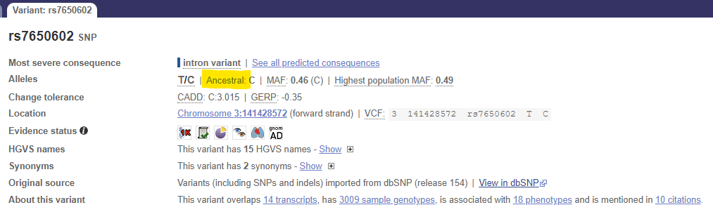

For our snp **rs7650602** the ancestral (older) allele is C. This means that the derived (newer) allele is T

### How old is the allele?

#### Across mammals or vertebrates

If the C allele is older, how long ago was the T allele introduced to humans? By looking at conservation across different groups of species we can try to determine if the derived allele existed prior to speciation.

We can look at this conservation in Ensembl or in the UCSC genome browswer. For this case I’ll use Ensembl.

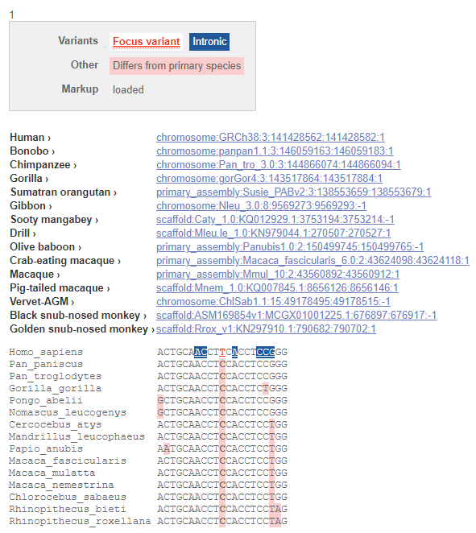

Our region of interest is in the Red T. You can see that at this position *all* the other species that have DNA that will align to this region have a C. This suggests that the C is highly conserved and old!

*Side note: The genomes on genome browsers are reference genomes. We know very little about the genomic diversity of most species. So having a C in one position doesn’t necessarily mean that no gorillas have a T. However, if T and C were both common across all the species we would expect that some of them would have T and some would have a C.*

#### Across great apes

As a part of the Great Ape Genome Project ( https://eichlerlab.gs.washington.edu/greatape/ ) multiple Great Ape genomes were sequenced. Using this data we can confirm (or refute) the hypothesis that great apes do not have a T at this position.

The Great Ape Files are in our labella_lab project space and are VCF Files. Importantly, the positions are **hg18** which is an old version of the human genome. Moreover, the VCF file **does not contain rs numbers**. Therefore we will need to find the position of our variant in hg18.

To find the variant in hg18 we will use an archive version of Ensembl BioMart. http://may2009.archive.ensembl.org/index.html

[figure not shown]

When we search for **rs7650602** we see it is at this position in hg18 3:142630104

We can then search the VCF files for this position (all the great ape genomes are labeled in reference to hg18). To do this we use vcftools which is already installed on the HPC

`ml vcftools`

`vcftools –gzvcf Pongo_pygmaeus.vcf.gz –chr 3 –from-bp 142630104 –to-bp 142630104`

Unfortunately in this species this region was not sequenced. So we get these results

VCFtools - 0.1.16

3. Adam Auton and Anthony Marcketta 2009

Parameters as interpreted:

--gzvcf Pongo_pygmaeus.vcf.gz

--chr 3

Using zlib version: 1.2.11

`After filtering, kept 5 out of 5 Individuals`

`After filtering, kept 0 out of a possible 78877390 Sites`

`No data left for analysis!`